[figure not shown]

# **TRABAJO FINAL**

## Franco Conde Sanchez

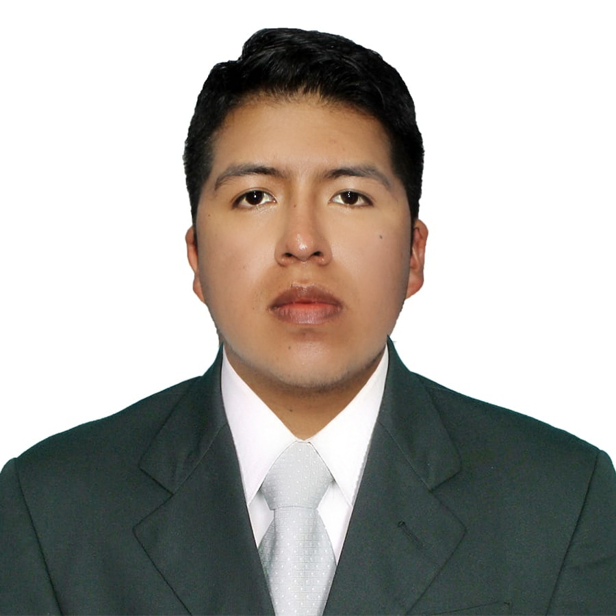

franconet12@gmail.com

## Fanor Flores

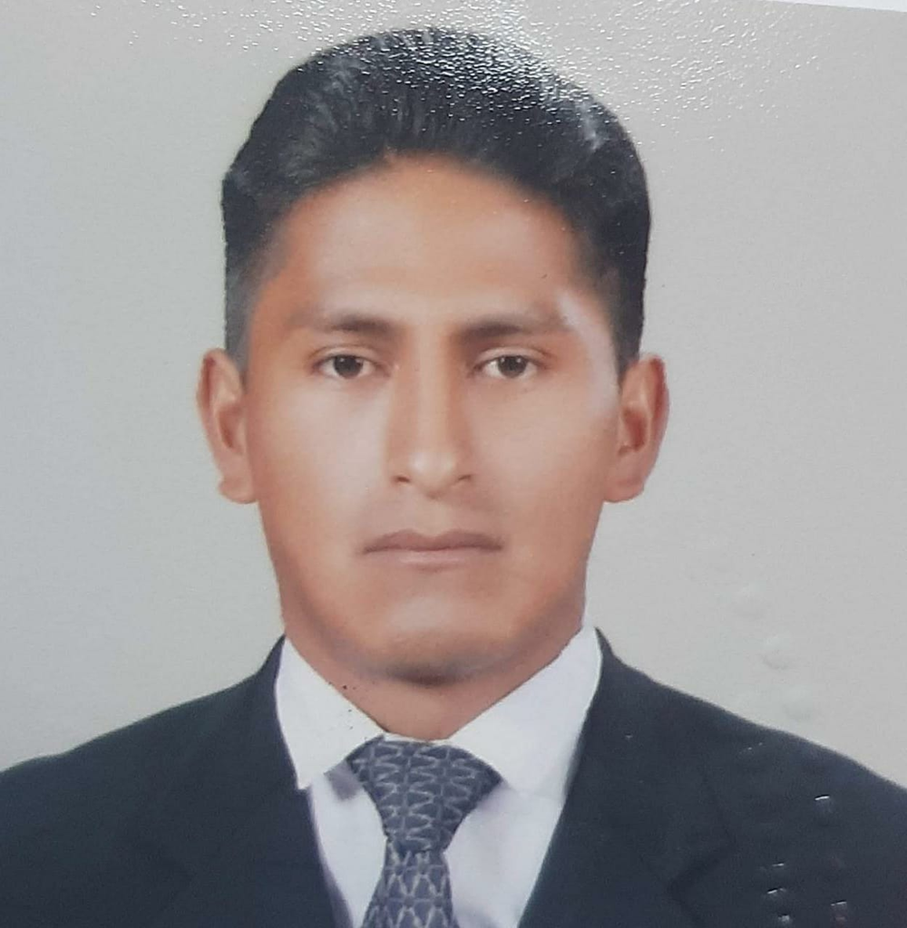

2020.fpf.men@gmail.com

# SITUACION PROBLEMA

En la cadena de suministro AVICOLA SOFIA se realizan procesos de negocios, que incluyen la gestión de: la demanda, las relaciones con los clientes, el servicio al cliente, el flujo de producción, la logística y las relaciones con los proveedores; así como el desarrollo y comercialización de nuevos productos. Todos se ejecutan con la finalidad de aumentar el grado de integración en la cadena de suministro avícola, logrando acelerar el flujo de los productos hasta el consumidor final.

Durante la fase de aprovisionamiento se realiza el proceso de gestión de las relaciones con los proveedores, a través de alianzas comerciales, tecnológicas y de producción que mejoran la comunicación en la cadena de suministro, aumentando así la efectividad en la adquisición y preparación de la materia prima. Destaca las alianzas de producción que permiten mantener el ritmo del flujo de materiales en la cadena de suministro, al conocer las necesidades de cada uno de los eslabones integradores.

En el mismo orden de ideas, existen 2 procesos de negocio que cruzan toda la cadena de suministro: la gestión logística y del flujo de producción. Al ser el pollo un producto de consumo masivo, es necesaria la aplicación de una estrategia de producción continua o bajo planeación en las fases de aprovisionamiento y procesamiento, para manejar el flujo de productos y satisfacer las necesidades del mercado de forma ininterrumpida. Además, la gestión logística acopla los tiempos de producción de los eslabones mediante el adecuado manejo de los inventarios y los almacenes, en conjunto con el desarrollo de políticas de transporte que permiten reducir los plazos de entrega de materiales.

En cuanto a la gestión de la relación con sus clientes, la industria avícola emplea canales para conducir sus productos hasta el consumidor final. Dichos canales de comercialización involucran agentes de ventas, mayoristas, puntos de venta y minoristas. Esta estrategia la realiza con la finalidad de poder abarcar el mercado de forma intensiva según lo planificado en el proceso de gestión de la demanda; sin embargo, debido a la actual falta de producción en la etapa de aprovisionamiento, el flujo continuo de materiales no se da con la suficiente intensidad para satisfacer el mercado meta de las empresas.

En síntesis, la cadena de suministro avícola posee un alto grado de integración gracias a sus procesos de negocio; principalmente los relacionados con los proveedores y clientes, aunado al de gestión logística, han permitido generar estrategias en la cadena de suministro para mantener su operatividad, a pesar de las adversas condiciones económicas, sociales y políticas (puedes referir a las económicas solamente). Las estrategias aplicadas por las empresas están dirigidas a satisfacer el mercado de Bolivia y a mantenerse competitivo en el mismo; desarrollando sus operaciones de acuerdo con las circunstancias, necesidades y expectativas de sus clientes, por lo que los clientes deciden abastcerse con el grupo de mayoristas causado por un falta de stock de la empresa causando insatisfaccion del cliente.

# DATOS DE ESTUDIO

```r
library(readxl)
Ventas <- read_excel("Ventas_Sofia.xlsx")
View(Ventas)

Ventas[c(1:13),]
```

```
## # A tibble: 13 x 6
##    Fecha               Tipo   Operación  Departameno `Cantidad de prod~ Ingresos
##    <dttm>              <chr>  <chr>      <chr>                    <dbl>    <dbl>
##  1 2017-01-01 00:00:00 CONGE~ MAYORISTAS COCHABAMBA               29100  2133903
##  2 2017-01-01 00:00:00 EMBUT~ SOFIA      SANTA CRUZ               19900  1945424
##  3 2017-01-01 00:00:00 EMBUT~ MAYORISTAS SANTA CRUZ                8200   712416
##  4 2017-01-02 00:00:00 CONGE~ MAYORISTAS SANTA CRUZ               28500  1815450
##  5 2017-01-02 00:00:00 CONGE~ SOFIA      EL ALTO                  15200  1138024
##  6 2017-01-03 00:00:00 POLLO  MAYORISTAS SANTA CRUZ               13100   953156
##  7 2017-01-03 00:00:00 CONGE~ MAYORISTAS EL ALTO                   6900   406686
##  8 2017-01-03 00:00:00 EMBUT~ SOFIA      SANTA CRUZ               23500  2158475
##  9 2017-01-04 00:00:00 POLLO  MAYORISTAS COCHABAMBA               10800  1024380
## 10 2017-01-04 00:00:00 CONGE~ SOFIA      COCHABAMBA               29900  2042768
## 11 2017-01-04 00:00:00 EMBUT~ MAYORISTAS SANTA CRUZ               12400   627068
## 12 2017-01-04 00:00:00 POLLO  SOFIA      SANTA CRUZ               18700   999328
## 13 2017-01-04 00:00:00 CONGE~ SOFIA      LA PAZ                   30000  2937300
```

# HACER UN ANALISIS EXPLORATORIO DE LOS DATOS

```r
summary(Ventas$`Cantidad de productos vendidos`)
```

```
##    Min. 1st Qu.  Median    Mean 3rd Qu.    Max.
##    4000   10500   17000   17025   23600   30000
```

# ESTABLECER SI EXISTE CORRELACION ENTRE LOS DATOS DE ESTUDIO

```r
density(Ventas$`Cantidad de productos vendidos`)
```

```
##
## Call:
##  density.default(x = Ventas$`Cantidad de productos vendidos`)
##
## Data: Ventas$`Cantidad de productos vendidos` (3337 obs.);   Bandwidth 'bw' = 1339
##
##        x                  y
##  Min.   :  -16.71   Min.   :5.119e-08
##  1st Qu.: 8491.65   1st Qu.:2.144e-05
##  Median :17000.00   Median :3.744e-05
##  Mean   :17000.00   Mean   :2.935e-05
##  3rd Qu.:25508.35   3rd Qu.:3.882e-05
##  Max.   :34016.71   Max.   :4.006e-05
```

```r
x<-density(Ventas$`Cantidad de productos vendidos`)
```

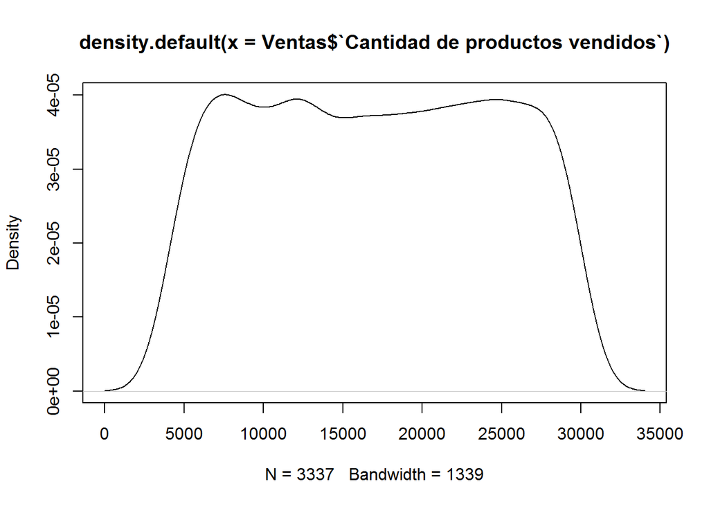

```r
plot(x)
```

## TOTAL VENDIDO POR MAYORISTAS Y SOFIA

```r
library(readxl)
total<- read_excel("Ventas_Sofia.xlsx",
    sheet = "Sugerencia2")
```

```
## * `` -> ...3
## * `` -> ...4
```

```r
View(total)

total[c(1:6),]
```

```
## # A tibble: 6 x 4
##   `Suma de Cantidad de productos vend~ `Etiquetas de column~ ...3    ...4
##   <chr>                                <chr>                 <chr>   <chr>
## 1 Etiquetas de fila                    MAYORISTAS            SOFIA   Total gene~
## 2 COCHABAMBA                           6664700               6655200 13319900
## 3 EL ALTO                              7452200               7008800 14461000
## 4 LA PAZ                               6937200               7482600 14419800
## 5 SANTA CRUZ                           6995500               7617100 14612600
## 6 Total general                        28049600              287637~ 56813300
```

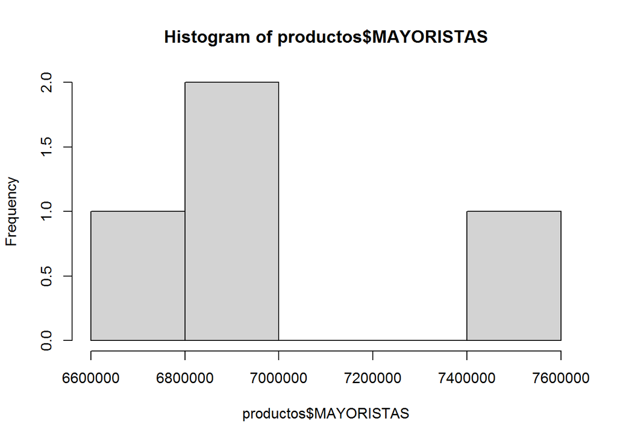

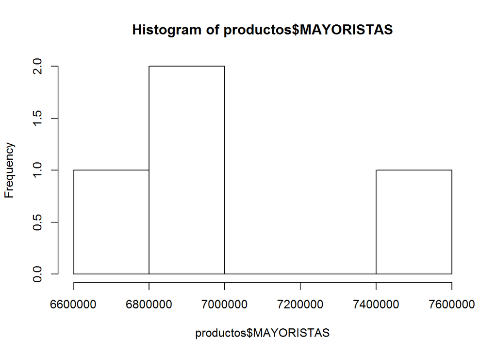

```r
library(readxl)
productos<- read_excel("Ventas_Sofia.xlsx",
    sheet = "Productos Vendidos")
View(productos)

plot(hist(productos$MAYORISTAS))
```

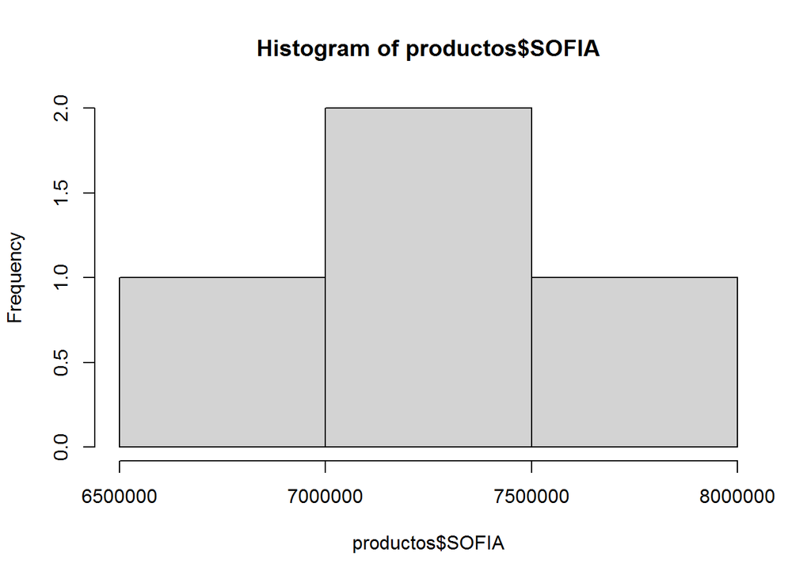

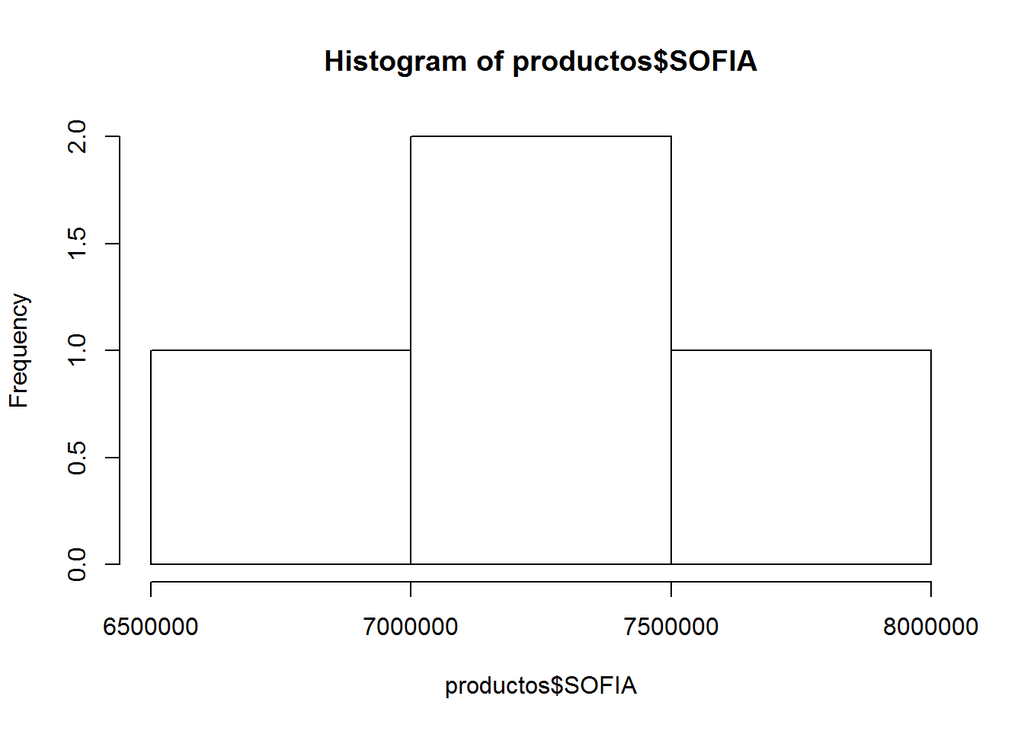

```r
plot(hist(productos$SOFIA))
```

## ESTABLECER SI EXISTE CORRELACION ENTRE LOS DATOS

```r
summary(productos)
```

```
##  Etiquetas de fila    MAYORISTAS          SOFIA         Total general
##  Length:4           Min.   :6664700   Min.   :6655200   Min.   :13319900
##  Class :character   1st Qu.:6869075   1st Qu.:6920400   1st Qu.:14144825
##  Mode  :character   Median :6966350   Median :7245700   Median :14440400
##                     Mean   :7012400   Mean   :7190925   Mean   :14203325
##                     3rd Qu.:7109675   3rd Qu.:7516225   3rd Qu.:14498900
##                     Max.   :7452200   Max.   :7617100   Max.   :14612600
```

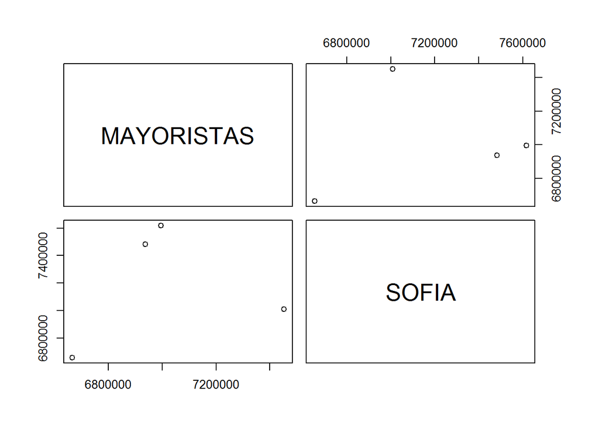

```r
library(psych)
pairs(productos[c(2,3)])
```